# Project - Linear Times Series

2025-04-10

https://www.insee.fr/fr/statistiques/serie/010767639#Graphique

## Part 0: the prerequisites

We first import all the packages that will be required for the following parts.

## Part I: the data

### Question 1

We will first import the data :

```r
ts <- read.csv("valeurs_mensuelles.csv", sep = ";")
ts <- ts[-c(1,2,3),-c(3)]
colnames(ts) <- c("date", "X")
ts$X <- as.numeric(ts$X)
ts$date <- as.yearmon(ts$date)
ts <- ts[dim(ts)[1]:1,]
prod <- zoo(ts$X, order.by = ts$date)
```

We drop the last two observations for predictions (see after)

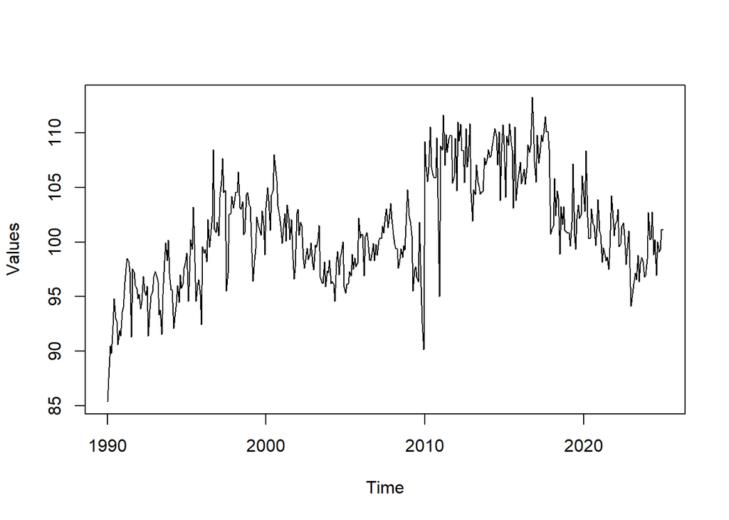

```r
prod_train <- prod[1:(length(prod)-2)]
plot(prod_train, xlab = "Time", ylab = "Values")
```

### Question 2

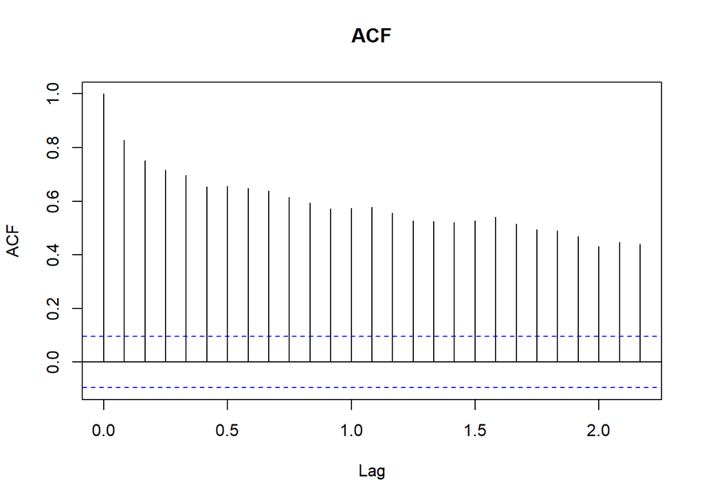

```r
acf(prod_train, main = "ACF")
```

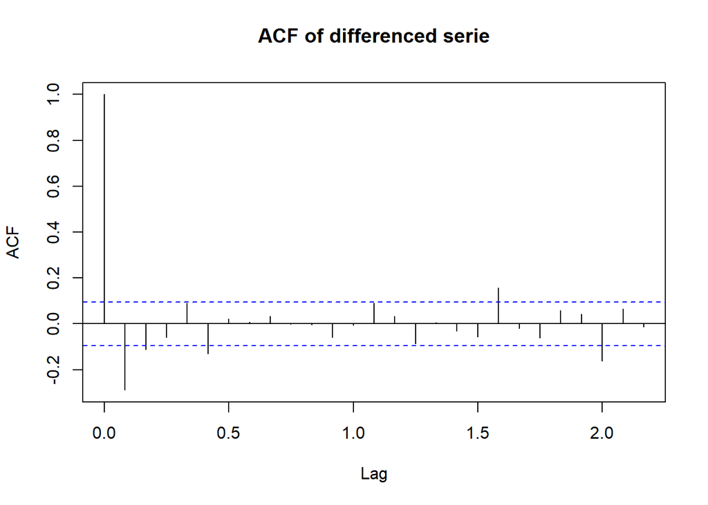

```r
dprod <- diff(prod_train,1)
acf(dprod, main = "ACF of differenced serie")
```

```r
dvalues <- coredata(dprod)

# dates
dates <- index(dprod)
time_num <- as.numeric(dates - dates[1])  # nombre de jours depuis la première date
df <- data.frame(time = time_num, valeur = dvalues)

reg <- lm(valeur ~ time, data = df)
summary(reg)
```

```
##
## Call:
## lm(formula = valeur ~ time, data = df)
##
## Residuals:
##     Min      1Q  Median      3Q     Max
## -9.3525 -1.4436  0.0588  1.3827 19.0583
##
## Coefficients:
##              Estimate Std. Error t value Pr(>|t|)
## (Intercept)  0.150455   0.269012   0.559    0.576
## time        -0.006465   0.013336  -0.485    0.628
##
## Residual standard error: 2.761 on 418 degrees of freedom
## Multiple R-squared:  0.0005618,  Adjusted R-squared:  -0.001829
## F-statistic: 0.235 on 1 and 418 DF,  p-value: 0.6281
```

The coefficients are not significant.

```r
adf.test(dvalues)
```

```
## Augmented Dickey-Fuller Test
## alternative: stationary
##
## Type 1: no drift no trend
##      lag   ADF p.value
## [1,]   0 -27.5    0.01
## [2,]   1 -20.4    0.01
## [3,]   2 -17.3    0.01
## [4,]   3 -13.6    0.01
## [5,]   4 -13.5    0.01
## [6,]   5 -12.3    0.01
## Type 2: with drift no trend
##      lag   ADF p.value
## [1,]   0 -27.5    0.01
## [2,]   1 -20.4    0.01
## [3,]   2 -17.3    0.01
## [4,]   3 -13.5    0.01
## [5,]   4 -13.5    0.01
## [6,]   5 -12.3    0.01
## Type 3: with drift and trend
##      lag   ADF p.value
## [1,]   0 -27.5    0.01
## [2,]   1 -20.4    0.01
## [3,]   2 -17.3    0.01
## [4,]   3 -13.6    0.01
## [5,]   4 -13.5    0.01
## [6,]   5 -12.3    0.01
## ----
## Note: in fact, p.value = 0.01 means p.value <= 0.01
```

the serie seems stationary.

Let’s take a look at two other tests

```r
pp.test(x=as.vector(dprod), output=TRUE) #Phillips-Perron test
```

```
## Phillips-Perron Unit Root Test
## alternative: stationary
##
## Type 1: no drift no trend
##  lag Z_rho p.value
##    5  -441    0.01
## -----
##  Type 2: with drift no trend
##  lag Z_rho p.value
##    5  -441    0.01
## -----
##  Type 3: with drift and trend
##  lag Z_rho p.value
##    5  -440    0.01
## ---------------
## Note: p-value = 0.01 means p.value <= 0.01
```

```r
kpss.test(x=as.vector(dprod)) #KPSS
```

```
## KPSS Unit Root Test
## alternative: nonstationary
##
## Type 1: no drift no trend
##  lag  stat p.value
##    4 0.225     0.1
## -----
##  Type 2: with drift no trend
##  lag   stat p.value
##    4 0.0724     0.1
## -----
##  Type 1: with drift and trend
##  lag   stat p.value
##    4 0.0189     0.1
## -----------
## Note: p.value = 0.01 means p.value <= 0.01
##     : p.value = 0.10 means p.value >= 0.10
```

The differenced serie looks stationnary

### Question 3

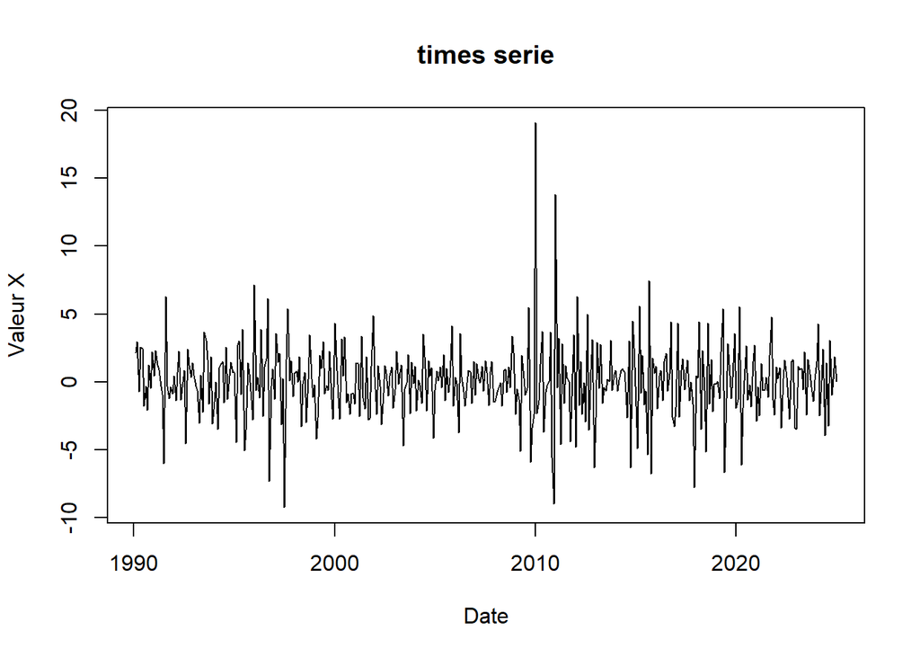

```r
plot(dprod, col = "black", xlab = "Date", ylab = "Valeur X", main = "times serie")
```

## Part II: ARMA Models

### Question 4

#### inference for p and q

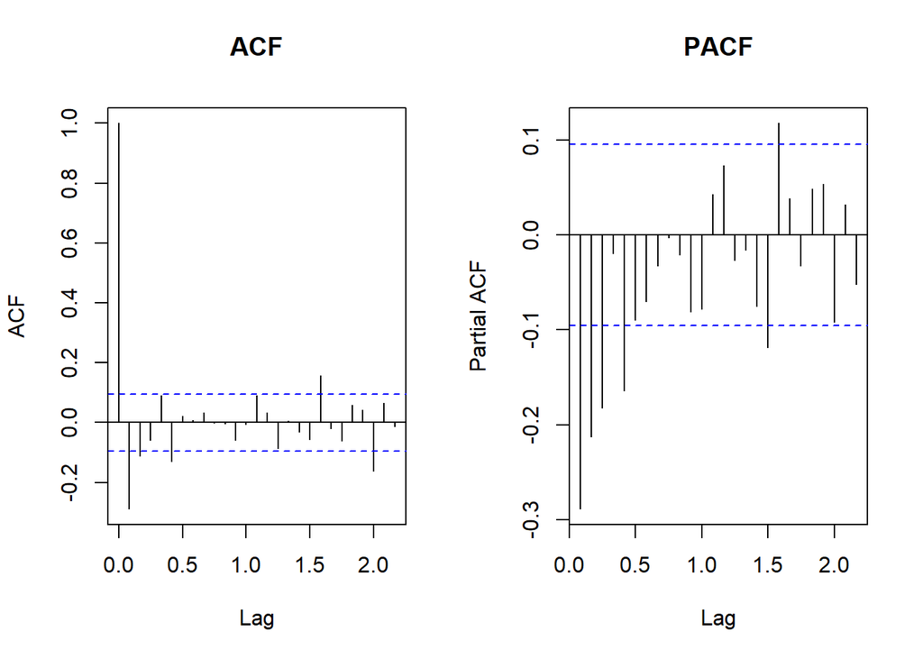

```r
par(mfrow = c(1, 2))  # 1 ligne, 2 colonnes
acf(dprod, main = "ACF")
pacf(dprod, main = "PACF")
```

```r
#From the plot we see that
pmax <- 1
qmax <- 5

#We create a loop to calculate the AIC/BIC for each possibility in the grid (qmax,pmax)=(1,5)
mat <- matrix(NA,nrow=pmax+1,ncol=qmax+1) #empty matrix to fill
rownames(mat) <- paste0("p=",0:pmax) #renames lines
colnames(mat) <- paste0("q=",0:qmax) #renames columns
AICs <- mat #AIC matrix not filled non remplie
BICs <- mat #BIC matrix not filled non remplie
pqs <- expand.grid(0:pmax,0:qmax) #all possible combinations of p and q
for (row in 1:dim(pqs)[1]){ #loop for each (p,q)
  p <- pqs[row,1] #gets p
  q <- pqs[row,2] #gets q
  estim <- try(arima(dprod,c(p,0,q),include.mean = F)) #tries ARIMA estimation
  AICs[p+1,q+1] <- if (class(estim)=="try-error") NA else estim$aic #assigns the AIC
  BICs[p+1,q+1] <- if (class(estim)=="try-error") NA else BIC(estim) #assigns the BIC
}

#Print the AICs
AICs
```

```
##          q=0      q=1      q=2      q=3      q=4      q=5
## p=0 2045.462 1983.588 1968.588 1967.244 1969.184 1965.056
## p=1 2011.006 1964.947 1966.930 1968.815 1970.623 1966.388
```

```r
AICs==min(AICs)
```

```
##       q=0   q=1   q=2   q=3   q=4   q=5
## p=0 FALSE FALSE FALSE FALSE FALSE FALSE
## p=1 FALSE  TRUE FALSE FALSE FALSE FALSE
```

```r
#The ARIMA(1,1,1) minimizes the AIC. We thus keep it.
arima111 <- Arima(prod_train, order = c(1,1,1), include.mean = FALSE)
```

We keep this model

```r
#Print the BICs
BICs
```

```
##          q=0      q=1      q=2      q=3      q=4      q=5
## p=0 2049.502 1991.669 1980.708 1983.405 1989.385 1989.298
## p=1 2019.086 1977.067 1983.091 1989.016 1994.865 1994.670
```

```r
BICs==min(BICs)
```

```
##       q=0   q=1   q=2   q=3   q=4   q=5
## p=0 FALSE FALSE FALSE FALSE FALSE FALSE
## p=1 FALSE  TRUE FALSE FALSE FALSE FALSE
```

Here too the ARIMA(1,1,1) is the best model regarding BIC.

Let’s take a deeper look We define a function to estimate ARIMA(p,1,q) models and assess their validity based on three criteria: significance of AR and MA coefficients, and absence of residual autocorrelation (via the Ljung-Box test at lag 30). The function returns a vector including the model orders (p, q), test results (arsignif, masignif, resnocorr), and an indicator ok equal to 1 if all checks are passed.

The arma_model_choice function applies this procedure to all combinations of (p, q) up to specified maxima (pmax, qmax), and stores the results in the arma_models table. We then extract valid models with ok = 1 into the selection object.

```r
p_value <- #This function returns the p-values of the estimated ARMA
  function(estim) {
    coef <- estim$coef
    se <- sqrt(diag(estim$var.coef))
    t <- coef / se
    pval <- (1 - pnorm(abs(t)))*2
    return(rbind(coef, se, pval))
  }

model_choice <- #This function estimates an arima and checks the fit and validity of the model with p-value
  function(p, q, data = dxm, k = 24) {
    estim <-
      try(arima(prod_train, c(p, 1, q), optim.control = list(maxit = 20000)))
    if (class(estim) == "try-error")
      return(c(
        "p" = p,
        "q" = q,
        "arsignif" = NA,
        "masignif" = NA,
        "resnocorr" = NA,
        "ok" = NA
      ))
    arsignif <- if (p == 0)
      NA
    else
      p_value(estim)[3, p] <= 0.05
    masignif <- if (q == 0)
      NA
    else
      p_value(estim)[3, p + q] <= 0.05
    resnocorr <-
      sum(Box.test(estim$residuals, lag = 30, type = "Ljung-Box")$p.value <= 0.05, na.rm =
            T) == 0
    checks <- c(arsignif, masignif, resnocorr)
    ok <-
      as.numeric(sum(checks, na.rm = T) == (3 - sum(is.na(checks))))
    return(
      c(
        "p" = p,
        "q" = q,
        "arsignif" = arsignif,
        "masignif" = masignif,
        "resnocorr" = resnocorr,
        "ok" = ok
      )
    )
  }


arma_model_choice <- #This function runs the previous one with all p<pmax & q<qmax
  function(pmax, qmax) {
    pqs <- expand.grid(0:pmax, 0:qmax)
    t(apply(matrix(1:dim(pqs)[1]), 1, function(row) {
      p <- pqs[row, 1]
      q <- pqs[row, 2]
      cat(paste0("Computing ARMA(", p, ",", q, ") \n"))
      model_choice(p, q)
    }))
  }

arma_models <- arma_model_choice(pmax, qmax)
```

```
## Computing ARMA(0,0)
## Computing ARMA(1,0)
## Computing ARMA(0,1)
## Computing ARMA(1,1)
## Computing ARMA(0,2)
## Computing ARMA(1,2)
## Computing ARMA(0,3)
## Computing ARMA(1,3)
## Computing ARMA(0,4)
## Computing ARMA(1,4)
## Computing ARMA(0,5)
## Computing ARMA(1,5)
```

```r
arma_models
```

```
##       p q arsignif masignif resnocorr ok
##  [1,] 0 0       NA       NA         0  0
##  [2,] 1 0        1       NA         0  0
##  [3,] 0 1       NA        1         0  0
##  [4,] 1 1        1        1         1  1
##  [5,] 0 2       NA        1         1  1
##  [6,] 1 2        1        0         1  0
##  [7,] 0 3       NA        0         1  0
##  [8,] 1 3        0        0         1  0
##  [9,] 0 4       NA        0         1  0
## [10,] 1 4        0        0         1  0
## [11,] 0 5       NA        1         1  1
## [12,] 1 5        0        1         1  0
```

```r
#We only keep models with the column "ok" equals to 1 (significant coefficients & non-autocorrelated residuals)

selection <- arma_models[arma_models[, "ok"] == 1 & !is.na(arma_models[, "ok"]),]
selection
```

```
##      p q arsignif masignif resnocorr ok
## [1,] 1 1        1        1         1  1
## [2,] 0 2       NA        1         1  1
## [3,] 0 5       NA        1         1  1
```

```r
# Ljung-Box on residuals
qtest_arima111 <- sapply(1:24, function(lag) {
  Box.test(arima111$residuals, lag = lag, type = "Ljung-Box", fitdf = length(arima111$coef) - 1)$p.value
})
names(qtest_arima111) <- paste0("Lag_", 1:24)
print(qtest_arima111)
```

```
##      Lag_1      Lag_2      Lag_3      Lag_4      Lag_5      Lag_6      Lag_7
## 0.00000000 0.94188521 0.99703204 0.41079314 0.15285415 0.23872020 0.33532772
##      Lag_8      Lag_9     Lag_10     Lag_11     Lag_12     Lag_13     Lag_14
## 0.39669175 0.50288035 0.59720562 0.57529584 0.66337166 0.48262655 0.53417371
##     Lag_15     Lag_16     Lag_17     Lag_18     Lag_19     Lag_20     Lag_21
## 0.41283486 0.47723302 0.50691200 0.54521655 0.14108331 0.17939486 0.19398615
##     Lag_22     Lag_23     Lag_24
## 0.21299843 0.25789910 0.03742285
```

Some lags are still significant.

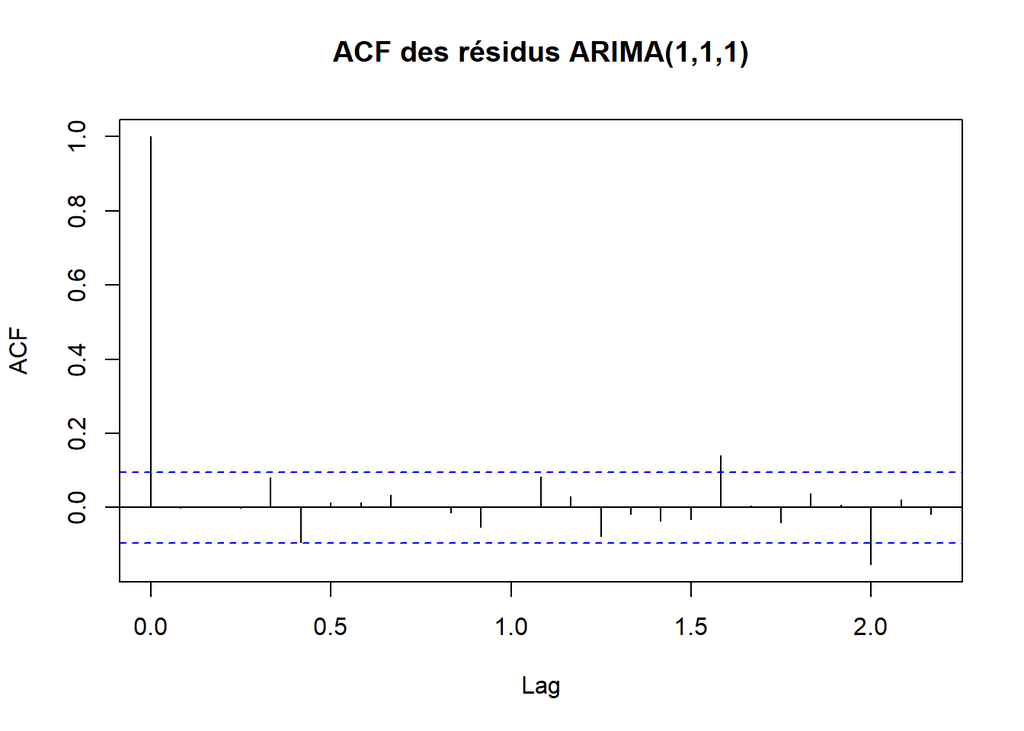

```r
acf(arima111$residuals, main = "ACF des résidus ARIMA(1,1,1)")
```

```r
coef <- arima111$coef
se <- sqrt(diag(arima111$var.coef))
tval <- coef / se
pval <- 2 * (1 - pnorm(abs(tval)))

results <- data.frame(
  Coefficient = round(coef, 3),
  Std.Error = round(se, 3),
  t.value = round(tval, 3),
  p.value = round(pval, 3)
)

kable(results, caption = "Estimated coefficients for ARIMA(1,1,1)")
```

Estimated coefficients for ARIMA(1,1,1)

|  | Coefficient | Std.Error | t.value | p.value |
| --- | --- | --- | --- | --- |
| ar1 | 0.391 | 0.072 | 5.398 | 0 |
| ma1 | -0.829 | 0.046 | -18.040 | 0 |